# testy

4/29/2018

## Workshop Prep

1. Open https://github.com/dlab-geo/r-geospatial-workshop
   - Download & unzip the zip file
   - Make a note of the folder in which it is located
2. Start **RStudio** and open a new script file
3. Install required libraries in RStudio - if you do not have them already

```r
install.packages(
  c("sp","rgdal","tmap","classInt","RColorBrewer",
    "ggplot2","leaflet", "ggmap"), dependencies=TRUE
)
```

## Geospatial Data in R

## Workshop Goals

Intro to working with geospatial data in R

- geospatial data files and formats
- Loading geospatial data in R
- R packages for working with geospatial data
- coordinate reference systems

Mapping geospatial data

Practice

## About Me

Patty Frontiera

dlab.berkeley.edu

## About you

Who are you?

Why are you here?

## Getting Started

1. Get the workshop files

https://github.com/dlab-geo/r-geospatial-workshop

- Click *Clone or Download* and download the zip file
- Upzip the zip file and make a note of the folder in which it is located

## Getting Started

1. Open RStudio and start a new script
2. Follow along by opening `r-geospatial-workshop-pt1.html`

## Getting Started

1. In RStudio, install required libraries in RStudio

```r
install.packages(
  c("sp","rgdal","tmap","classInt","RColorBrewer",
    "ggplot2","leaflet", "ggmap"), dependencies=TRUE
)
```

## Geographic Data

## Geographic Data

are data about *locations* on or near the surface of the *Earth*.

[figure not shown]

## Geospatial data

represent location more specifically with **coordinates**

`46.130479, -117.134167`

[figure not shown]

## Coordinate Reference Systems

Coordinates only make sense when associated with a CRS!

[figure not shown]

Geographic Coordinates: `Latitude` and `Longitude`

## Coordinate Reference Systems

Define:

- the shape of the Earth
- the origin (0,0 point)
- the relationship between the system and the real world
- the units

*Because of variations in 1-3, there are **many** geographic CRSs!*

## WGS84

The [World Geodetic System of 1984](https://en.wikipedia.org/wiki/World_Geodetic_System) is the most widely used geographic coordinate reference system.

`WGS84` is the default CRS for most GIS software

Almost all longitude and latitude data are assumed to be **WGS84** unless otherwise specified

*Historical data much trickier*

## Geospatial data are powerful!

You can

- dynamically determine spatial metrics like area, length, distance and direction
- spatial relationships like intersects, inside, contains, etc

and

- link data by location, like census data and crime data

## Spatial Data

Spatial data is a broader term than geographic data.

Methods for working with spatial data are valid for geospatial data

All spatial data are encoded with some type of coordinate reference system

Geospatial data require the CRS to be a model of locations on the Earth

## Types of Spatial Data

## Types of Spatial Data

Vector and Raster Data

## Vector Data

Points, lines and Polygons

[figure not shown]

## Raster Data

Regular grid of cells (or pixels)

[figure not shown]

- We won't be covering Raster data in this workshop*

## Softare for working with Geospatial Data

## Geospatial data require

software that can import, create, store, edit, visualize and analyze geospatial data

- represented as geometric data objects *referenced to the surface of the earth via CRSs*
- with methods to operate on those representations

## GIS

We call software for working with geospatial data **GIS**

**Geographic Information System**

This term is commonly associated with desktop software applications.

## Types of GIS Software

Desktop GIS - `ArcGIS`, `QGIS`

Spatial Databases - `PostgreSQL/PostGIS`

Web-based GIS - `ArcGIS Online`, `CARTO`

Software geospatial data support - `Tableau`

Programming languages with geospatial data support

- `R`, `Python`, `Javascript`

## Why R for Geospatial Data?

## Why R for Geospatial Data?

You already use R

Reproducibility

Free & Open Source

Strong support for geospatial data and analysis

Cutting edge

## Geospatial Data in R

## Geospatial Data in R

There are many approaches to and packages for working with geospatial data in R.

One approach is to keep it simple and store geospatial data in a data frame.

This approach is most common when

- the data are point data in CSV files and
- you want to map rather than spatially transform or analyze the data

## About the Sample Data

**San Francisco Open Data Portal** https://data.sfgov.org

[SF Property Tax Rolls](https://data.sfgov.org/Housing-and-Buildings/Assessor-Historical-Secured-Property-Tax-Rolls/wv5m-vpq2)

This data set includes the Office of the Assessor-Recorder’s secured property tax roll spanning from 2007 to 2016.

We are using a subset of this data as a proxy for home values.

## Load the CSV file into a data frame

```r
sfhomes <- read.csv('data/sf_properties_25ksample.csv',
                    stringsAsFactors = FALSE)

# Take a look at first 5 rows and a few of the columns
sfhomes[1:5,c("YearBuilt","totvalue","AreaSquareFeet","Neighborhood",
              "NumBedrooms")]
```

```
##   YearBuilt totvalue AreaSquareFeet       Neighborhood NumBedrooms
## 1      1923  1031391           2250 West of Twin Peaks           0
## 2      1909   775300           5830   Presidio Heights           3
## 3      1915  1116772           1350     Inner Richmond           2
## 4      1947   860130           1162    Sunset/Parkside           0
## 5      1981   322749           1463     Outer Richmond           3
```

*Make sure your working directory is set to the folder where you downloaded the workshop files!*

## Explore the data

```r
class(sfhomes)            # what is the data object type?
dim(sfhomes)              # how many rows and columns
str(sfhomes)              # display the structure of the object
head(sfhomes)             # take a look at the first 10 records
summary(sfhomes)          # explore the range of values
summary(sfhomes$totvalue) # explore the range of values for one column
hist(sfhomes$totvalue)    # histogram for the totvalue column
```

## Questions:

- What columns contain the geographic data?
- Are these data vector or raster data?
- What type of geometry do the data contain?
  - Points, lines, polygons, grid cells?
- What is the CRS of these data?

## Plot of points

Use the R base `plot` function to create a simple map

```r
plot(sfhomes$lon, sfhomes$lat) # using base plot function
```

## Plot of points

Use the R base `plot` function to create a simple map

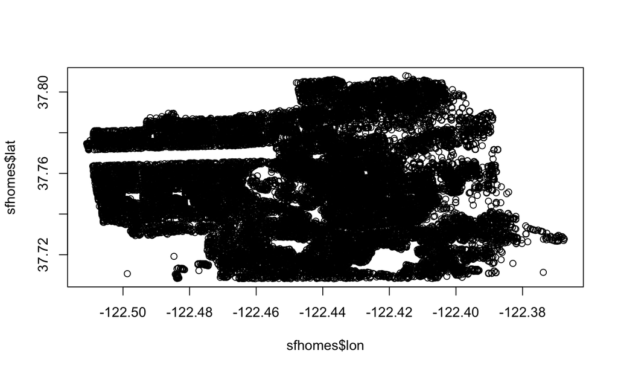

```r
plot(sfhomes$lon, sfhomes$lat) # using base plot function
```